# ILC Cell Line Encyclopedia (ICLE) Data Analysis

### SupFig 8C: SV Count per Chromosome

Bar plot of SV count per chromosome.

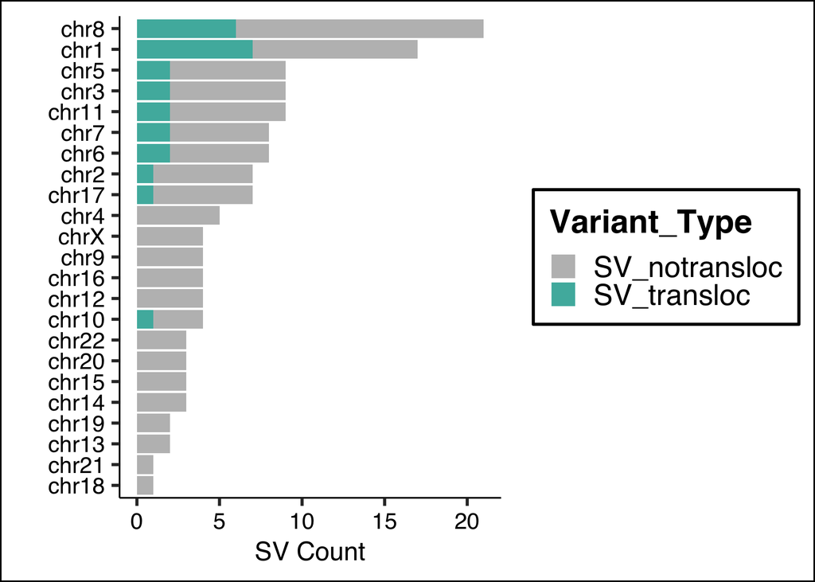

```r
ggsave(file.path(DIRS$results_sub$ogm, "SupFig8C_SV_Per_Chr.pdf"), SupFig8C, width = 7, height = 5)
SupFig8C
```

### SupFig 8D: Somatic Mutation Count per Chromosome

Bar plot of Mutation count per chromosome

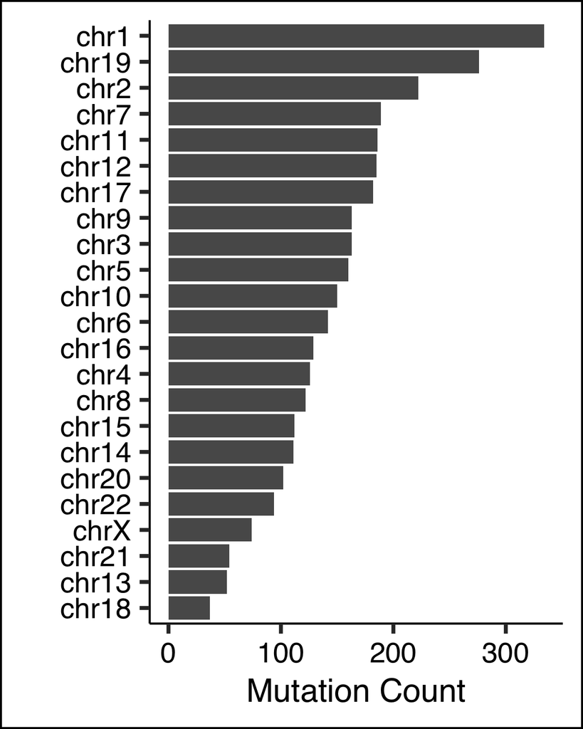

```r
ggsave(file.path(DIRS$results_sub$ogm, "SupFig8D_Mutations_Per_Chr.pdf"), SupFig8D, width = 4, height = 5)
SupFig8D
```

### SupFig 9: OGM Circos Plots

Generates individual OGM circos plots for every ICLE cell line using the same `interacCircos`-based pipeline as Fig 3D. All plots are saved as PDFs to `SupFig9_OGM_Circos/`. This chunk may take several minutes to complete depending on SV count.

```r
draw_circos_plot_for_all(shatterseek_outs$sv_df, shatterseek_outs$cnv_df, shatterseek_outs$chromothripsis_df,
                         out_dir = file.path(DIRS$results_sub$ogm, "SupFig9_OGM_Circos"))
```

```
## [1] "Making Circos Plot for: HCC1187"

## file:////Users/oshah/Documents/ICLE/3-Results/Optical_Genome_Mapping/SupFig9_OGM_Circos/HCC1187_circos_plot.html screenshot completed

##   Saved PDF for sample: HCC1187

## [1] "Making Circos Plot for: HCC2218"

## file:////Users/oshah/Documents/ICLE/3-Results/Optical_Genome_Mapping/SupFig9_OGM_Circos/HCC2218_circos_plot.html screenshot completed

##   Saved PDF for sample: HCC2218

## [1] "Making Circos Plot for: IPH926"

## file:////Users/oshah/Documents/ICLE/3-Results/Optical_Genome_Mapping/SupFig9_OGM_Circos/IPH926_circos_plot.html screenshot completed

##   Saved PDF for sample: IPH926

## [1] "Making Circos Plot for: MDAMB134VI"

## file:////Users/oshah/Documents/ICLE/3-Results/Optical_Genome_Mapping/SupFig9_OGM_Circos/MDAMB134VI_circos_plot.html screenshot completed

##   Saved PDF for sample: MDAMB134VI

## [1] "Making Circos Plot for: MDAMB330"

## file:////Users/oshah/Documents/ICLE/3-Results/Optical_Genome_Mapping/SupFig9_OGM_Circos/MDAMB330_circos_plot.html screenshot completed

##   Saved PDF for sample: MDAMB330

## [1] "Making Circos Plot for: MDAMB453"

## file:////Users/oshah/Documents/ICLE/3-Results/Optical_Genome_Mapping/SupFig9_OGM_Circos/MDAMB453_circos_plot.html screenshot completed

##   Saved PDF for sample: MDAMB453

## [1] "Making Circos Plot for: 600MPE"

## file:////Users/oshah/Documents/ICLE/3-Results/Optical_Genome_Mapping/SupFig9_OGM_Circos/600MPE_circos_plot.html screenshot completed

```

[output cut: 46 more lines]

```
## file:////Users/oshah/Documents/ICLE/3-Results/Optical_Genome_Mapping/SupFig9_OGM_Circos/SKBR3_circos_plot.html screenshot completed

##   Saved PDF for sample: SKBR3

## [1] "Making Circos Plot for: UACC3133"

## file:////Users/oshah/Documents/ICLE/3-Results/Optical_Genome_Mapping/SupFig9_OGM_Circos/UACC3133_circos_plot.html screenshot completed

##   Saved PDF for sample: UACC3133

## [1] "Making Circos Plot for: ZR7530"

## file:////Users/oshah/Documents/ICLE/3-Results/Optical_Genome_Mapping/SupFig9_OGM_Circos/ZR7530_circos_plot.html screenshot completed

##   Saved PDF for sample: ZR7530
```

### SupFig 10: Functional Fusions Landscape

Chromosomal breakpoint heatmap showing which chromosome pairs are recurrently involved in functional (GOE or LOE) fusions across ICLE cell lines.

```r
# SupFig 10A: Fusion Breakpoints Heatmap
pdf(file.path(DIRS$results_sub$ogm, "SupFig10A_Functional_Fusions_Chr_Heatmap.pdf"), width = 6.5, height = 5)
  draw(supfig10a_fusion_breakpoints_ht, merge_legends = TRUE)
dev.off()
```

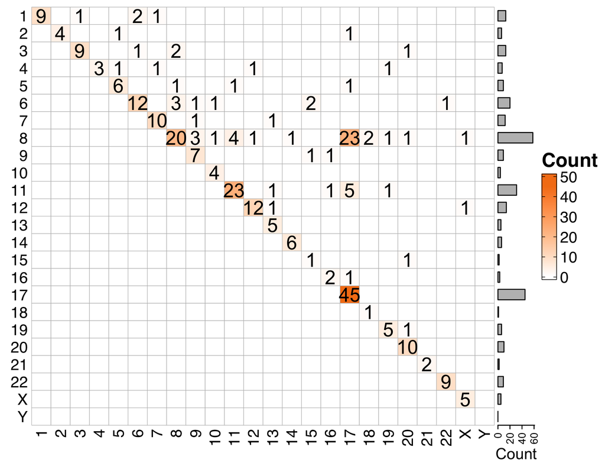

```r
draw(supfig10a_fusion_breakpoints_ht, merge_legends = TRUE)
```

```r
# SupFig 10B: Recurring fusions expression heatmap
pdf(file.path(DIRS$results_sub$ogm, "SupFig10B_Recurring_Functional_Fusions.pdf"), width = 15, height = 5)
  draw(supfig10b_recurring_fusions_ht, merge_legends = TRUE)
dev.off()
```

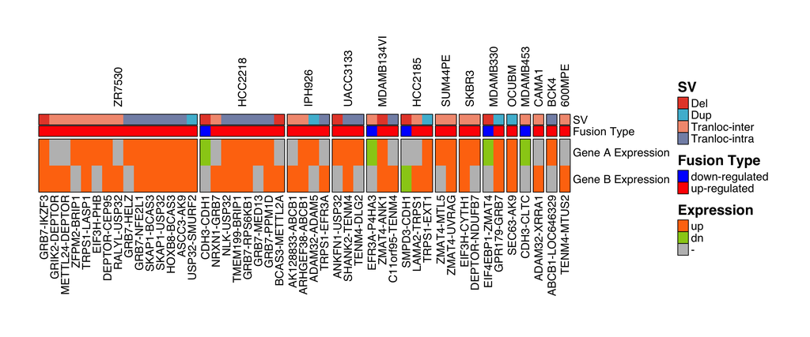

```r
draw(supfig10b_recurring_fusions_ht, merge_legends = TRUE)
```

Gene-specific circos plots for each recurrently fused gene

```r
# SupFig 10C: Recurring gene circos plots
gene_names <- names(recurring_gene_circos)
for (i in seq_along(gene_names)) {
    gene <- gene_names[i]
    pdf_file <- file.path(DIRS$results_sub$ogm,
                         paste0("SupFig10C_", gene, "_Fusions.pdf"))
    pdf(pdf_file, width = 7, height = 7)
    print(recurring_gene_circos[[gene]])
    dev.off()
}
```

## d. Global Methylation Instability and Epigenetic Regulation of ILC Driver Genes

The orchestrator script `21_Fig4_SupFig11_DNAm_Alterations.R` performs: 1. **DMI scoring** — sum of absolute β-value deviations from normal-tissue medians across all shared probes (TCGA adjacent-normal as reference); pairwise comparisons by two-sided t-test (Holm correction). 2. **Differential methylation** — limma on M-values comparing Luminal A ILC vs NST in tumors and cell lines (FDR < 0.05, |log fold-change| ≥ 0.5). 3. **Differential expression** — DESeq2 on matched RNA-seq (FDR < 0.05, |log₂FC| ≥ 1). 4. **Consensus DNAm-regulated genes** — intersection of significant differential probes and genes with inverse DNAm–expression correlation in both tumors and cell lines.

```r
source(file.path(DIRS$scripts$helpers, "21_Fig4_SupFig11_DNAm_Alterations.R"), chdir = TRUE)
```

```
## ===============================================================================

## Section 1: Loading Data

## ===============================================================================

## Loading Oncovar annotations...

## Loading HM450K probe set...

## Loading RNA-seq data...

## Loading cell line DNA methylation data...

## TCGA DNA methylation data already loaded

##   Common probes across datasets: 75646

##
## ===============================================================================

## Section 2: Calculating DMI (DNA Methylation Index)

## ===============================================================================

##   Step 1: Calculating median DNA methylation in normal samples...

##     Calculated median beta for 75646 probes

##   Step 2: Calculating Global Methylation Aberration (GMA) scores...

##   Patient tumors: 651 samples

##   Cell lines: 49 samples

##   Step 3: Combining patient and cell line data...

##   Step 4: Defining group variables...

##   Filtered to 700 samples (Cell Lines: 49. Normal: 98. Patient Tumors: 553. )
```

[output cut: 143 more lines]

```
## Script 22 completed successfully!

## ===============================================================================

##   All figures assigned to global environment for saving in Main_Data_Analysis.Rmd

##   - SupFig11: tumor_pam50, cl_pam50, tumor_cl_histology_LumA

##   - Fig4A: tissue_dmi

##   - Fig4B: dnma_lfc_plt

##   - Fig4C: fig4c_ht

##   - Fig4D: fig4e
```

### SupFig 11: DNAm Instability Score (DMI) by PAM50 Subtype and Histology

```r
ggsave(file.path(dnam_dir, "SupFig11A_DMI_Tumor_PAM50.pdf"), tumor_pam50, width = 5, height = 3)

pdf(file.path(dnam_dir, "SupFig11A_DMI_Tumor_PAM50_pvalue_table.pdf"), width = 10, height = 10)
  gridExtra::grid.table(signif(SupFig11A_pval_table, 1))
dev.off()
```

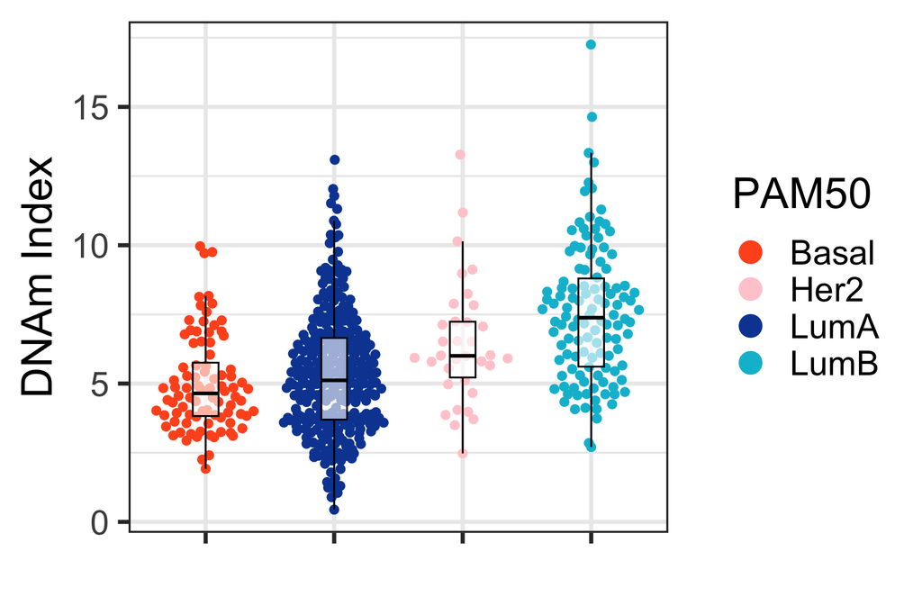

```r
tumor_pam50
```

```r
ggsave(file.path(dnam_dir, "SupFig11B_DMI_CL_PAM50.pdf"), cl_pam50, width = 5, height = 3)

pdf(file.path(dnam_dir, "SupFig11B_DMI_CL_PAM50_pvalue_table.pdf"), width = 10, height = 10)
  gridExtra::grid.table(signif(SupFig11B_pval_table, 1))
dev.off()
```

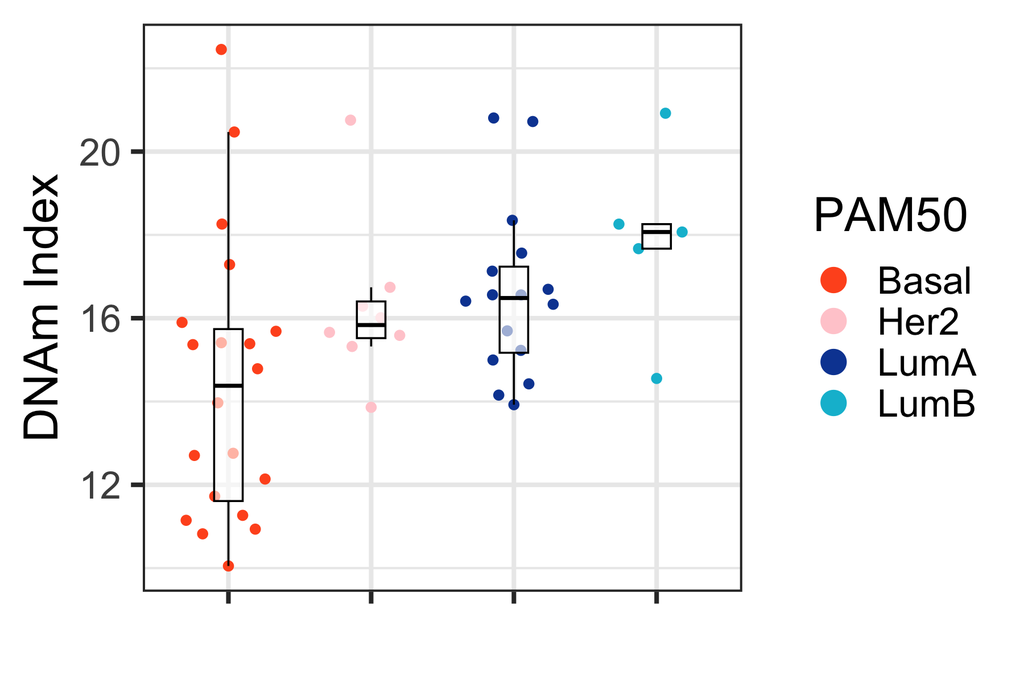

```r
cl_pam50
```

```r
ggsave(file.path(dnam_dir, "SupFig11C_DMI_Tumor_CL_Histology.pdf"), tumor_cl_histology_LumA, width = 4, height = 3)

pdf(file.path(dnam_dir, "SupFig11C_DMI_Tumor_CL_Histology_pvalues_table.pdf"), width = 10, height = 10)
  gridExtra::grid.table(signif(SupFig11C_pval_table, 1))
dev.off()
```

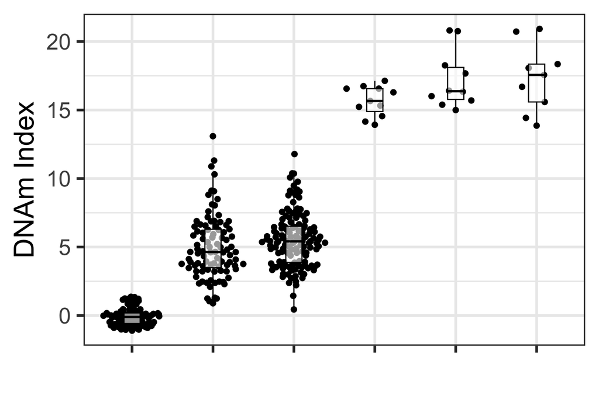

```r
tumor_cl_histology_LumA
```

### Figure 4A: DNAm Instability Score (DMI) by Specimen Type

Violin/box plot of DMI scores stratified by specimen type: normal breast tissue, TCGA primary BRCA tumors (ILC and NST), and integrated BRCA cell lines (ILC-like and NST). Demonstrates progressively elevated methylation instability from normal tissue through primary tumors to cell lines.

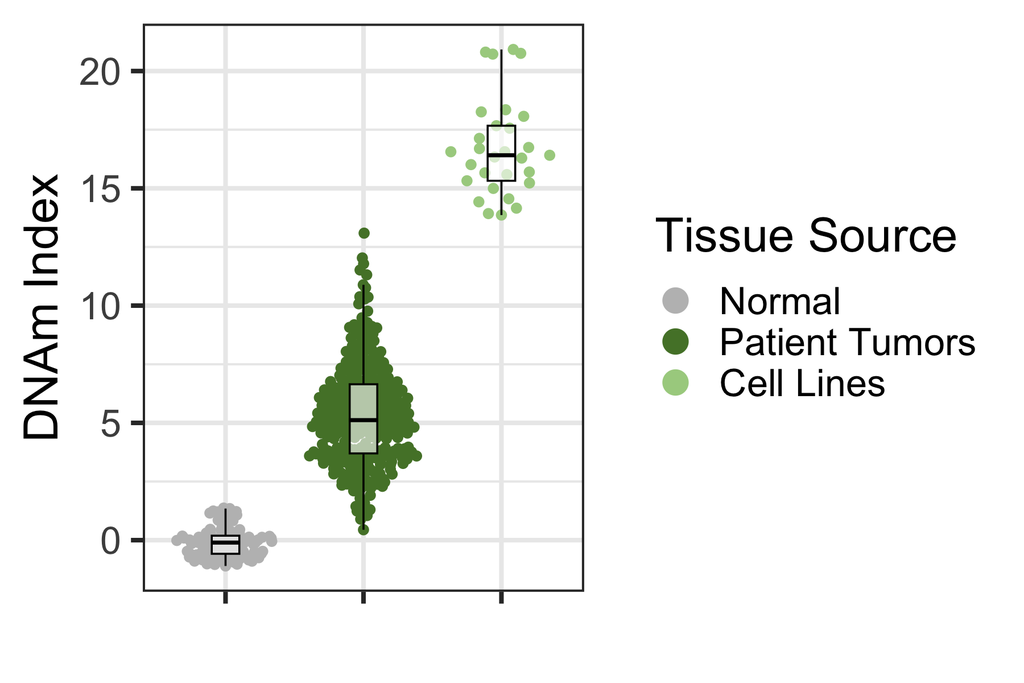

```r
ggsave(file.path(DIRS$results_sub$dna_methylation, "Fig4A_DMI_Normal_Tumor_CL.pdf"),
       tissue_dmi, width = 5, height = 3)
gt::gtsave(tissue_dmi_pval, file.path(DIRS$results_sub$dna_methylation, "Fig4A_DMI_Normal_Tumor_CL_pvalue_table.html"))

tissue_dmi
```

### Figure 4B: Consensus DNAm–mRNA Alterations (Patient Tumors and Cell Lines)

Scatter plot of genes with concordant differential methylation and gene expression in Luminal A ILC vs NST, comparing results in TCGA tumors and integrated BRCA cell lines. Points in the highlighted quadrants represent consensus genes with inverse probe methylation and mRNA expression changes.

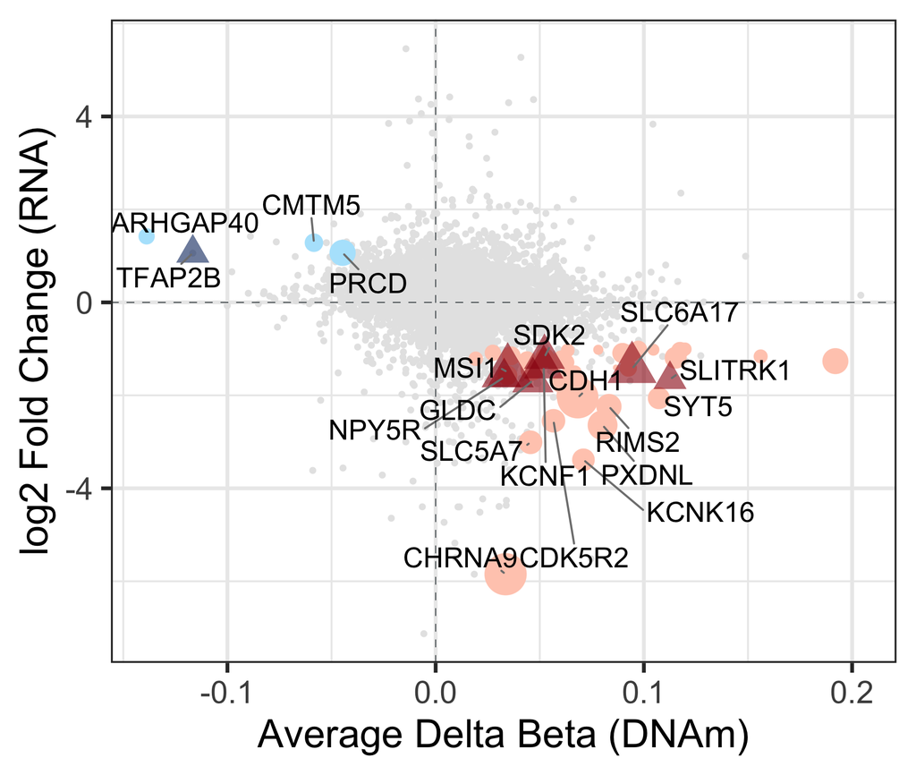

```r
ggsave(file.path(DIRS$results_sub$dna_methylation, "Fig4B_Tumor_RNA_DNAm_Alterations_small_height.pdf"),
       dnma_lfc_plt, width = 6, height = 5)
dnma_lfc_plt
```

### Figure 4C: Consensus DNAm-Regulated Genes

Heatmap displaying consensus DNAm-regulated genes (from Fig 4B) across TCGA tumors and integrated BRCA cell lines.

```r
pdf(file.path(DIRS$results_sub$dna_methylation, "Fig4C_Alterations_Heatmap.pdf"), width = 10, height = 5)
  draw(fig4c_ht, merge_legends = TRUE, gap = unit(0.1, "cm"))
dev.off()
```

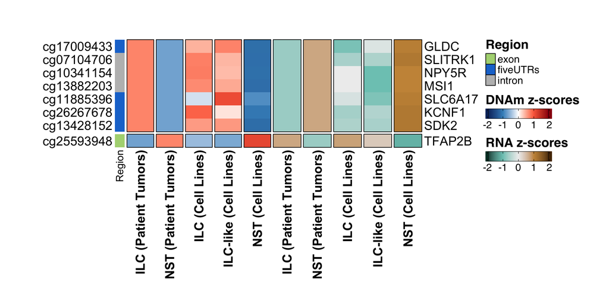

```r
draw(fig4c_ht, merge_legends = TRUE, gap = unit(0.1, "cm"))
```

### Figure 4D: Top Consensus DNAm-Regulated Genes — Expression and Methylation Barplots

Paired barplots showing row normalized RNA expression and DNAm for *MSI1* and *TFAP2B* across BRCA cell lines.

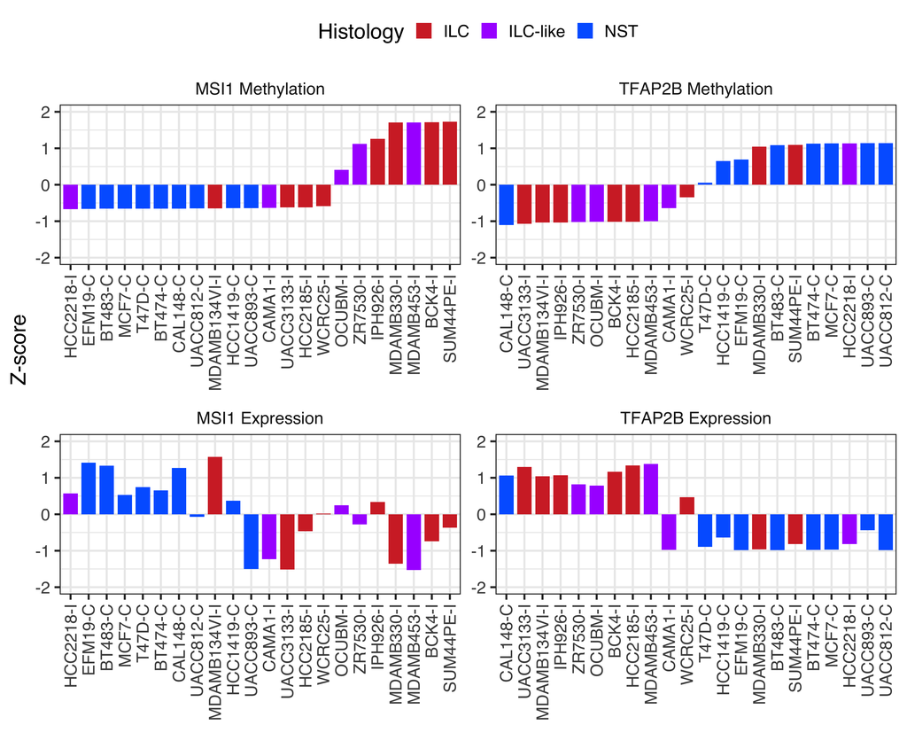

```r
ggsave(file.path(DIRS$results_sub$dna_methylation, "Fig4D_Top_Alterations_Barplots.pdf"), fig4e, width = 12, height = 10)
fig4e
```

## e. Identification of ILC-Specific Gene Dependencies and Nomination of Druggable Targets

Identifies ILC-specific gene dependencies from the Marcotte et al. RNAi loss-of-function screen using a consensus two-pipeline approach: (1) **Limma-D2** — DEMETER2-preprocessed RNAi viability scores (DepMap) followed by limma differential analysis; (2) **siMEM** — integrated preprocessing and differential analysis using the siMEM algorithm (Marcotte et al. 2016). Consensus dependencies are defined as genes with nominal p ≤ 0.05 in both pipelines. High- and low-dependency gene sets are then subjected to KEGG pathway over-representation analysis (hypeR) and queried against DGIdb to nominate therapeutic targets.

```r
source(file.path(DIRS$scripts$helpers, "22_Fig5_RNAi_Differential_Dependencies.R"), chdir = TRUE)
```

```
## ===============================================================================

## Section 2: Loading RNAi Data

## ===============================================================================

## Loading RNAi data...

## ✓ Loaded 15256 genes across 19 cell lines
## ===============================================================================
## Section 3: SIMEM Differential Analysis
## ===============================================================================
## Loading existing SIMEM results...
## ✓ Loaded SIMEM results for 14730 genes
## ===============================================================================
## Section 4: D2 Differential Analysis
## ===============================================================================
## ✓ Analyzed 13607 genes
## ===============================================================================
## Section 5: Computing Consensus Dependencies
## ===============================================================================
## ✓ Consensus dependencies: 93
## Adding drug-gene interaction information...
## ✓ Added DGI information for 2396 genes
## ✓ Saved results to: /Users/oshah/Documents/ICLE/3-Results/Gene_Dependencies/RNAi_ILC_Consensus_Dependencies.tsv
## ========================================
## Figure 5B: Consensus dependencies scatter plot
## ========================================
## ✓ Fig 5B complete (fig5b_consensus_dep_plt assigned).
## ========================================
## SupFig 12: Consensus dependencies heatmap
## ========================================
## ✓ SupFig 12 complete (supfig12_dep_ht assigned).
## ========================================
## Figure 5C: KEGG pathway enrichment
## ========================================
## ✓ Fig 5C complete (fig5c_pathway_plt assigned).
## ========================================
## Figure 5D: Pathway level dependencies heatmap
## ========================================
## ✓ Fig 5D complete (fig5d_pathway_ht assigned).
## ========================================
## Figure 5E: Druggable dependencies heatmap
## ========================================
## ✓ Fig 5E complete (fig5e_drug_ht assigned).
## ========================================
## Figure 5 (5B–5E) and SupFig 12 complete
## ========================================
## - Fig 5B: fig5b_consensus_dep_plt
## - SupFig 12: supfig12_dep_ht
## - Fig 5C: fig5c_pathway_plt
## - Fig 5D: fig5d_pathway_ht
## - Fig 5E: fig5e_drug_ht
```

### Figure 5A: ILC-Specific Dependency Analysis — Study Schematic

```r
# Figure 5A is a schematic/workflow illustration produced in Adobe Illustrator.
# Overview schematic of the dual-pipeline ILC dependency discovery workflow (Limma-D2 and siMEM) and the downstream druggability Prioritization strategy.
```

### Figure 5B: Consensus ILC-Specific Differential Dependencies

Scatter plot showing effect sizes of differential dependencies (ILC vs NST cell lines) from Limma-D2 and siMEM pipelines. Point colors highlight dependencies identified as significant by both (consensus) or only one of the two pipelines.

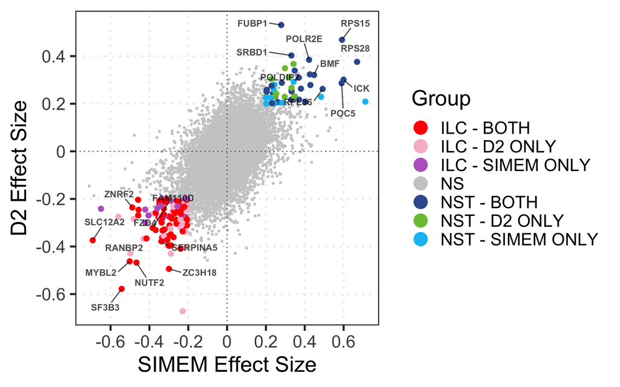

```r
ggsave(file.path(DIRS$results_sub$dependencies, "Fig5b_Differential_Dependencies.pdf"),
       fig5b_consensus_dep_plt, width = 8, height = 4.5)
fig5b_consensus_dep_plt
```

### SupFig 12: Consensus Differential Dependencies Heatmap

Hierarchically clustered heatmap of all consensus ILC-specific differential dependency genes across Marcotte et al. RNAi cell lines, annotated by histological subtype (ILC, NST).

```r
pdf(file.path(DIRS$results_sub$dependencies, "SupFig12_Consensus_Dependencies_Heatmap.pdf"),
    width = 7.5, height = 16)
  draw(supfig12_dep_ht, merge_legends = TRUE, heatmap_legend_side = "bottom")
dev.off()
```

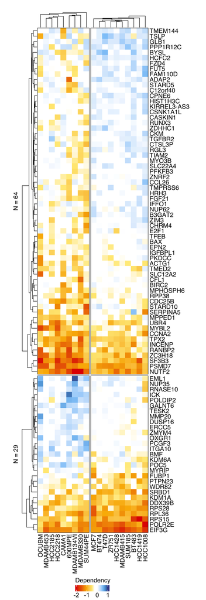

```r
draw(supfig12_dep_ht, merge_legends = TRUE, heatmap_legend_side = "bottom")
```

### Figure 5C: KEGG Pathway Over-Representation in ILC-Specific Dependency Genes

Barplot showing hypergeometric over-representation analysis of KEGG pathways in ILC vs NST differential dependencies.

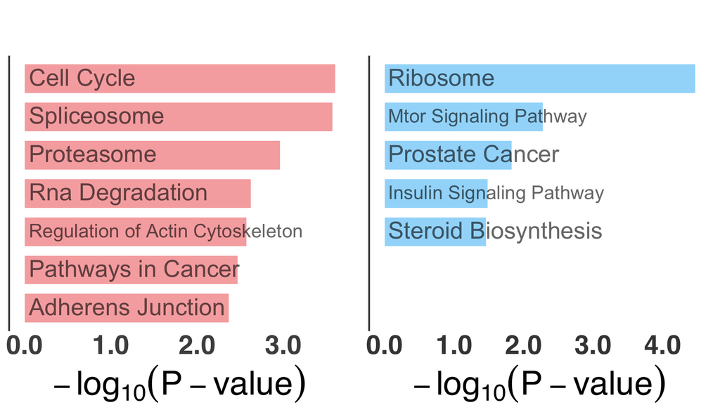

```r
ggsave(file.path(DIRS$results_sub$dependencies, "Fig5C_KEGG_ORA.pdf"), fig5c_pathway_plt, width = 6, height = 3.5)
fig5c_pathway_plt
```

### Figure 5D: Pathway-Level Dependency Scores

Heatmap of pathway-level summary dependency scores (mean gene-level dependency/viability scores per KEGG pathway) across cell lines, stratified by ILC vs NST histology. Condenses gene-level signals into interpretable pathway vulnerabilities.

```r
pdf(file.path(DIRS$results_sub$dependencies, "Fig5D_Pathway_Scores.pdf"), width = 7.5, height = 5)
  draw(fig5d_pathway_ht, merge_legends = TRUE, heatmap_legend_side = "bottom")
dev.off()
```

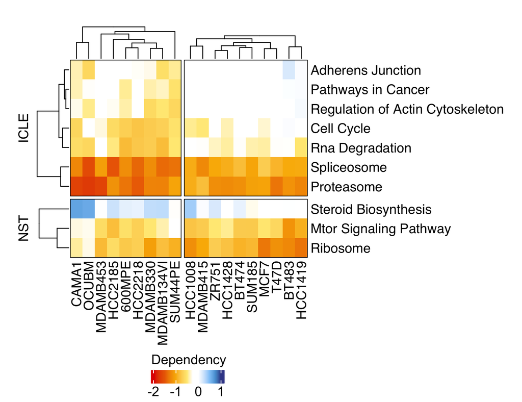

```r
draw(fig5d_pathway_ht, merge_legends = TRUE, heatmap_legend_side = "bottom")
```

### Figure 5E: Druggable ILC Dependencies — Prioritized Therapeutic Targets

Heatmap of the top ILC-specific dependency genes with annotated drug interactions from the Drug Gene Interaction database (DGIdb; Wagner et al. 2016).

```r
pdf(file.path(DIRS$results_sub$dependencies, "Fig5E_ILC_Druggable_Dependencies.pdf"), width = 7.5, height = 5)
  draw(fig5e_drug_ht, merge_legends = TRUE, heatmap_legend_side = "bottom")
dev.off()
```

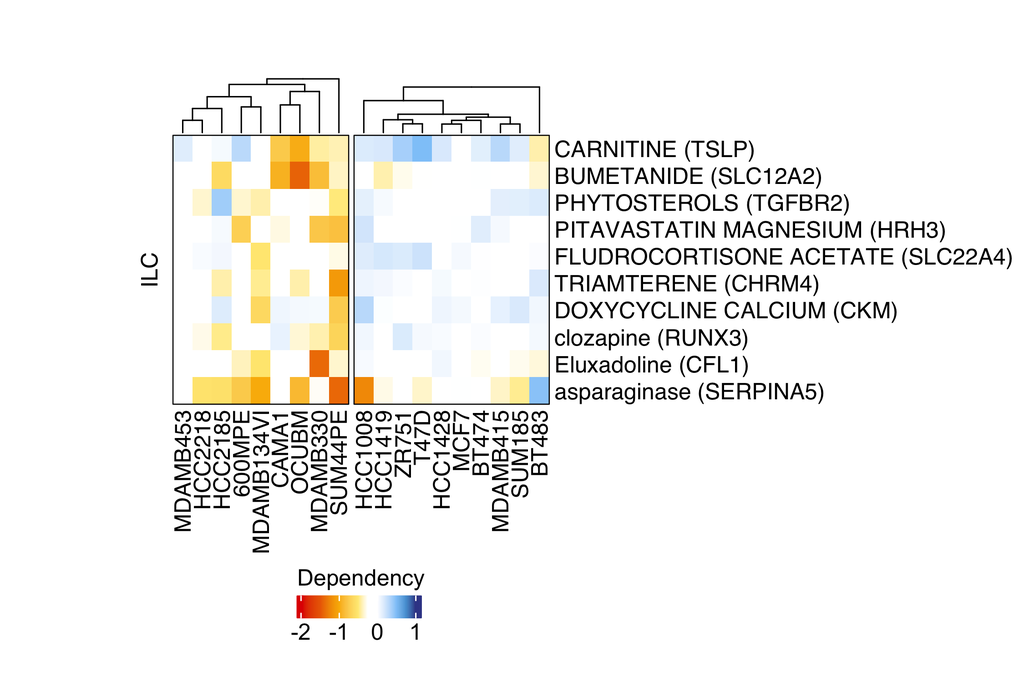

```r
draw(fig5e_drug_ht, merge_legends = TRUE, heatmap_legend_side = "bottom")
```